# Endangered Languages Exploration

## by Jean Pierre Simons Rondona

## Overview

### Dataset Structure

Less Critical -> Most Critical

- Vulnerable - most children speak the language, but it may be restricted to certain domains (e.g., home)
- Definitely endangered - children no longer learn the language as a 'mother tongue' in the home
- Severely endangered - language is spoken by grandparents and older generations; while the parent generation may understand it, they do not speak it to children or among themselves
- Critically endangered - the youngest speakers are grandparents and older, and they speak the language partially and infrequently
- Extinct - there are no speakers left

### Points of interest

The key areas of interest is the factors correlated to a languages degree of endangerment.

I expect the countries population demographics, total number of remaining speakers along with the location to be the main factors correlated to a critically endangered language.

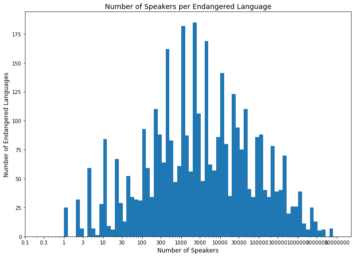

```python
#Set figure size
plt.figure(figsize=[ 11.69, 8.27])
# Set bin size. The min is set to 0 since we don't need to take into account extinct languages
bins = 10 ** np.arange(0, 7+0.1, 0.1)
# Modify the ticks to make the x-axis more readable
ticks = [0.1, 0.3, 1, 3, 10, 30, 100, 300, 1000,3000,10000,30000, 100000, 300000, 1000000, 3000000, 10000000]
labels = ['{}'.format(v) for v in ticks]
plt.hist(data = non_extinct, x = 'Number of speakers', bins=bins);
# Apply  a logarithmic axis scale
plt.xscale('log')
# Apply the ticks we defined to our plot
plt.xticks(ticks,labels);
# Apply x-axis label
plt.xlabel('Number of Speakers', fontsize=12)
plt.ylabel('Number of Endangered Languages', fontsize=12)
plt.title('Number of Speakers per Endangered Language', fontsize=14)
plt.show()
```

Next, let's see the criticality across all of the endangered languages out there.

As you can see below, it looks like the bulk of the languages are not in critical endangerment so the scenario is not so grimm for the majority as their future lies with the children!

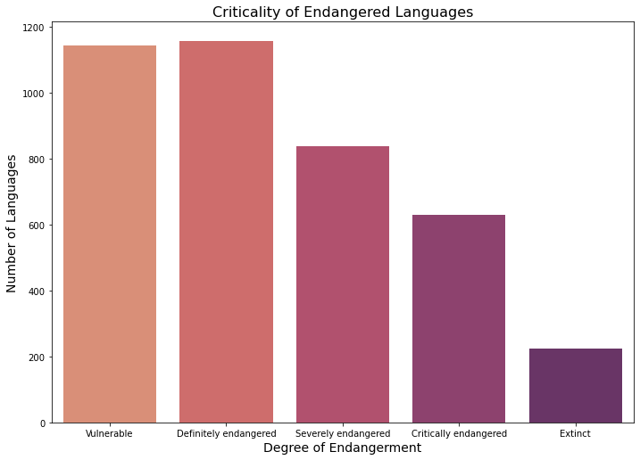

```python
# Countplot based on Degree of Endangerement
plt.figure(figsize=[ 11.69, 8.27])
base_color = sb.color_palette()[0]
sb.countplot(data=end_lang, x='Degree of endangerment', palette='flare', linewidth=False)
plt.ylabel('Number of Languages',fontsize=14)
plt.xlabel('Degree of Endangerment',fontsize=14)
plt.title('Criticality of Endangered Languages', fontsize=16)
plt.show()
```

Here we can see a bivariate scatterplot (degree of endangerement vs # of speakers). As expected, the critically endangered languages have very few speakers left for the most part, which you can see given the high concentration under 500 for the critically endangered. The higher the degree of endangerment, the lower the amount of speakers left.

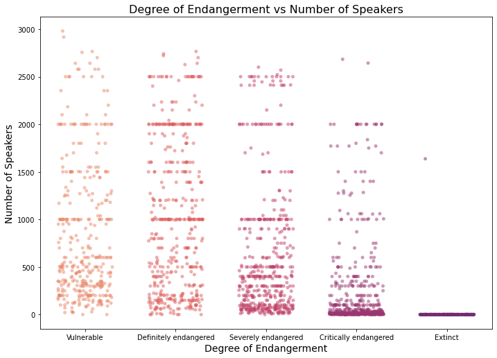

```python
# Filter out Number of Speakers > 3000
end_lang2 = end_lang[end_lang['Number of speakers'] < 3000]
plt.figure(figsize=[ 11.69, 8.27])
sb.stripplot(data = end_lang2, x='Degree of endangerment', y='Number of speakers', jitter=0.3, alpha=0.50, palette='flare');
plt.xlabel('Degree of Endangerment', fontsize=14)
plt.ylabel('Number of Speakers',fontsize=14)
plt.title('Degree of Endangerment vs Number of Speakers',fontsize=16)
plt.show()
```

Next let's see what are the countries with less than 50 speakers to get a sense of their location.

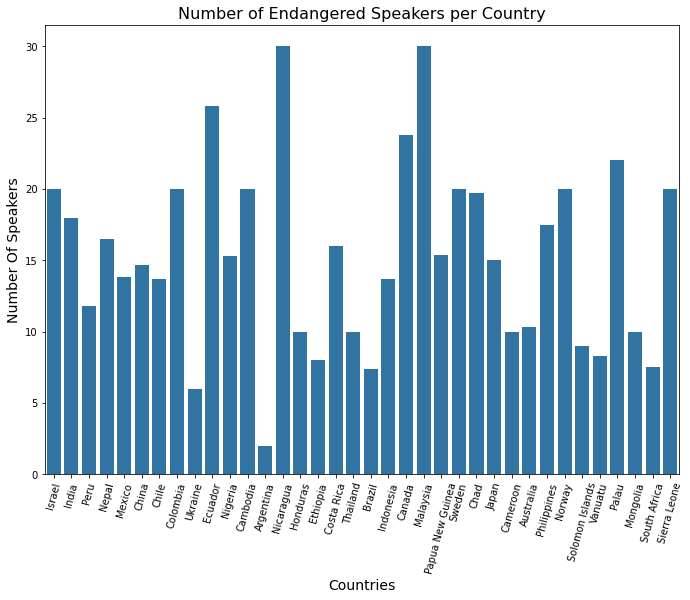

```python
# Barplot for Number of Speakers per Country (top 10 with the least speakers)
plt.figure(figsize=[ 25, 8.27])
plt.subplot(1,2,1)
sb.barplot(data=ten_least_spoken, x = 'Countries', y = 'Number of speakers', ci=None, color=base_color)
plt.xticks(rotation=75);
plt.xlabel('Countries',fontsize=14)
plt.ylabel('Number Of Speakers', fontsize=14)
plt.title('Number of Endangered Speakers per Country',fontsize=16)
plt.show()
```

On first impression it looks like most countries are in Latin America, Africa, and Southeast Asia. Let's do some analysis based on the hemisphere in which the endangered languages are located.

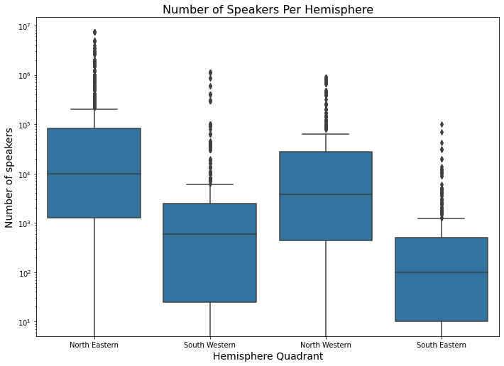

```python
# Let's see the number of endangered speakers per hemisphere via a box plot

plt.figure(figsize=[ 11.69, 8.27])
base_color = sb.color_palette()[0]


#  box plot
sb.boxplot(data=end_lang, x='Hemisphere Quadrant', y='Number of speakers', color=base_color)
#plt.xticks(rotation=15);
#plt.ylim(ax1.get_ylim()) # set y-axis limits to be same as left plot
plt.yscale('log');
plt.title('Number of Speakers Per Hemisphere', fontsize=16)
plt.xlabel('Hemisphere Quadrant', fontsize=14)
plt.ylabel('Number of speakers', fontsize=14)
plt.show()
```

Now let's see where the extinct languages are located in terms of hemisphere.

[figure not shown]

```python
#Extinct languages by hemisphere.
extinct = end_lang[end_lang['Degree of endangerment'] == 'Extinct']
#Reset the categories to exclude "Extinct"
end_cats = ['Extinct']
cat_type = CategoricalDtype(categories=end_cats, ordered=True)
extinct['Degree of endangerment'] = extinct['Degree of endangerment'].astype(cat_type)

#Plot graph
plt.figure(figsize=[ 11.69, 8.27])
base_color = sb.color_palette()[0]
sb.countplot(data=end_lang, x='Hemisphere Quadrant', color=base_color, linewidth=False)
plt.ylabel('Number of Extinct Languages', fontsize=14)
plt.xlabel('Hemisphere Quadrant',fontsize=14)
plt.title('Extinct Languages Per Hemisphere', fontsize=16)
plt.show()
```

For our final visualization, below we can see a multivariable bar plot with the correlation between # of speakers per language, Hemisphere language location, and Degree of Endangerment.

It looks like the North Eastern hemisphere has the most speakers per endangered language. This could be due to the fact that China and India are very densely populated countries.

In addition we can see that the South Eastern and South Western hemispheres have the least amount of speakers per critically endangered language. More research is needed but perhaps the fact that both of these areas were heavily colonized has an impact on these numbers.

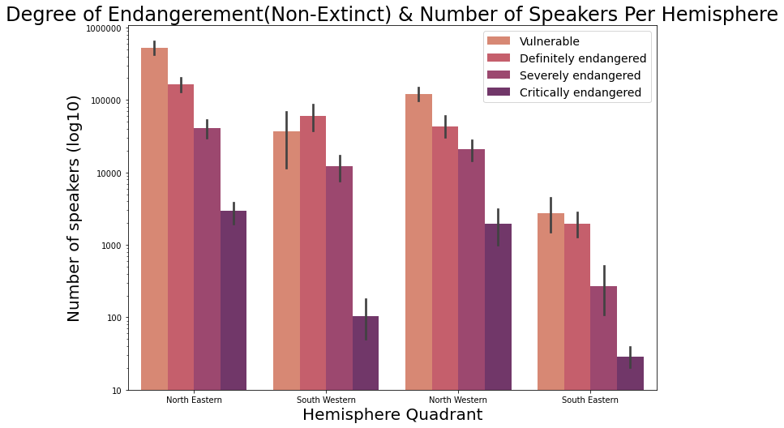

```python
plt.figure(figsize=[ 11.69, 8.27])
# Let's plot a barchart for non-extinct degrees of endagerment (since we won't be able to use a logarithmic scale if we include those)
non_extinct = end_lang[end_lang['Degree of endangerment'] != 'Extinct']
#Reset the categories to exclude "Extinct"
end_cats = ['Vulnerable','Definitely endangered','Severely endangered','Critically endangered']
cat_type = CategoricalDtype(categories=end_cats, ordered=True)
non_extinct['Degree of endangerment'] = non_extinct['Degree of endangerment'].astype(cat_type)

#Plot graph
ax = sb.barplot(data= non_extinct, x = 'Hemisphere Quadrant', y = 'Number of speakers', hue = 'Degree of endangerment', palette='flare');
plt.yscale('log')
plt.ylabel('Number of speakers (log10)', fontsize=20)
plt.xlabel('Hemisphere Quadrant', fontsize=20)
ticks = [10,100, 1000, 10000,100000,1000000]
labels = ['{}'.format(v) for v in ticks]
plt.yticks(ticks,labels);
plt.title('Degree of Endangerement(Non-Extinct) & Number of Speakers Per Hemisphere', fontsize=24)
plt.legend(fontsize=14)
#sb.color_palette("YlOrBr", as_cmap=True)
plt.show()
```